# Analiza retelelor in R

Nicula Florin (Gr 405)

Orosanu Claudiu (Gr 405)

17 December 2018

Instalarea resurselor necesare

```r
library(devtools)
install_github("DougLuke/UserNetR")
```

# **Vizualizarea retelelor**

## **1. Tehnici de plotare si layout**

Reprezentarea vizuala a retelelor este o provocare. Numarul de moduri in care o retea poate fi reprezentata vizual este practic infinit. Un grafic sugestiv va transmite informatiile importante despre retea, cum ar fi structura generala, locatia actorilor importanti din retea, prezenta unor subgrupuri distinctive. De asemenea, informatia irelevanta trebuie sa fie cat mai putina.

```r
library(statnet)
library(UserNetR)
data(Moreno)
```

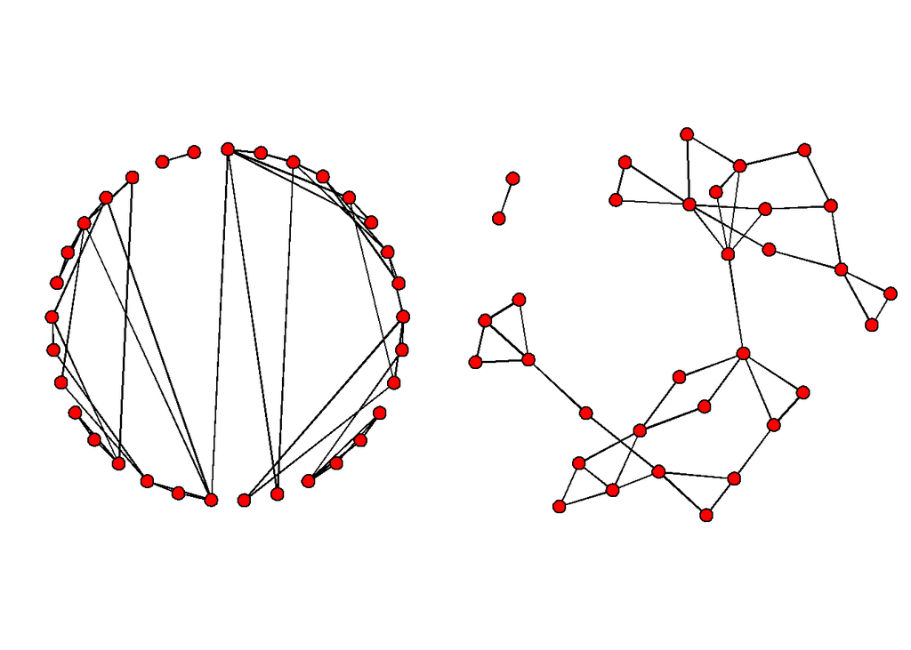

```r
op <- par(mar = rep(0, 4),mfrow=c(1,2))
plot(Moreno,mode="circle",vertex.cex=1.5)
plot(Moreno,mode="fruchtermanreingold",vertex.cex=1.5)
```

```r
par(op)
```

Moreno este o retea ce modeleaza relatiile de prietenie dintre copii de clasa a 4 a.

La prima vedere, cele doua grafice par a fi foarte diferite. Totusi, ele sunt construite pe baza aceleiasi retele (Moreno). Se observa aici faptul ca graficul din partea dreapta este mult mai usor de interpretat. Se pot distinge doua componenete separate ale retelei, iar componenta mai mare este si ea impartita la randul ei intre doua componente.

Lungimea muchiilor in aceste grafice nu are nicio insemnatate. Alegerea la intamplare a acestor lungimi poate induce in eroare.

### **Principii estetice in reprezentarea retelelor**

Din cercetarile facute in acest domeniu, au reiesit cateva principii care ajuta la reprezentarea corecta a retelelor.

- Cat mai putine intersectii ale muchiilor
- Simetria nodurilor in retea trebuie sa fie cat mai mare
- Lungimea muchiilor trebuie sa varieze cat mai putin
- Atunci cand doua muchii se intersecteaza, unghiul format trebuie sa fie cat mai mare
- Minimizarea spatiului pentru reprezentarea retelei

Mai multe abordari au aparut in ceea ce priveste reprezentarea automata a unei retele. O varianta populara este urmatoarea: nodurile conectate se “atrag”, in timp ce o forta repulsiva actioneaza intre toate perechile de noduri. Reteaua va oscila pentru un timp, dar la un moment dat se va stabiliza, iar energia din sistem va fi minima.

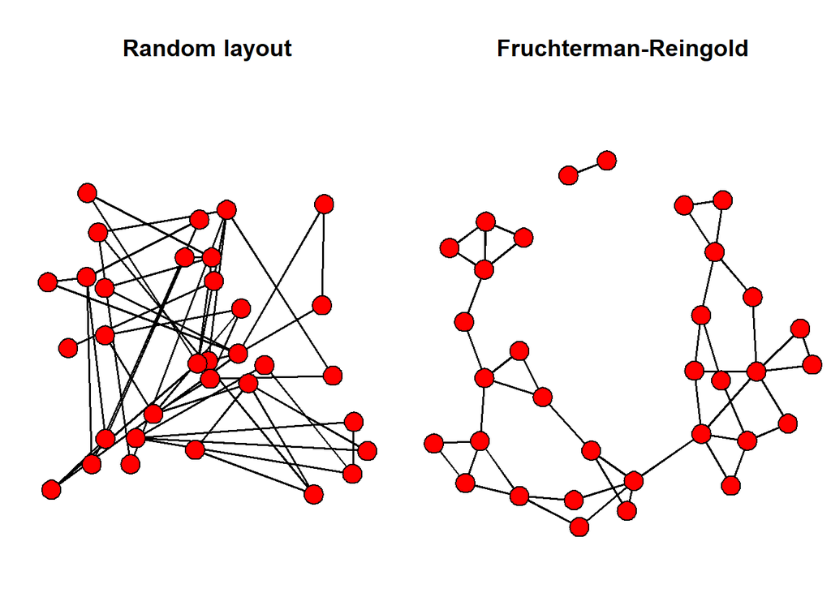

```r
op <- par(mar = c(0,0,4,0),mfrow=c(1,2))
gplot(Moreno,gmode="graph",mode="random",vertex.cex=1.5,main="Random layout")
gplot(Moreno,gmode="graph",mode="fruchtermanreingold",vertex.cex=1.5,main="Fruchterman-Reingold")
```

```r
par(op)
```

Graficul din dreapta este realizat cu algoritmul *Fruchterman-Reingold*, care actioneaza cum am precizat mai sus, facand parte din clasa algoritmilor *force-directed*. Se observa ca toate principiile estetice enumerate mai sus sunt respectate.

Algoritmii *force-directed* sunt iterativi si non-deterministici. Asta inseamna ca graficul rezultat nu va fi identic, la fiecare rulare, insa va fi destul de similar.

### **Algoritmi si metode de plotare**

In libraria *statnet*, exista doua functii prin care se poate realiza un grafic al unei retele: *plot* si *gplot*. Folosing functia *gplot* avem mai multe optiuni de layout, prin argumentul *mode*.

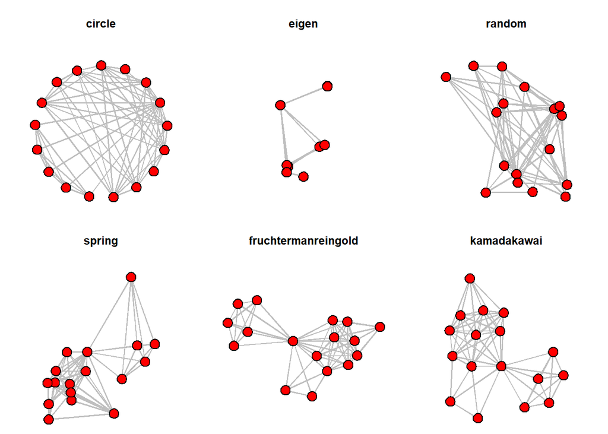

```r
op <- par(mar=c(0,0,4,0),mfrow=c(2,3))

gplot(Bali,gmode="graph",edge.col="grey75",vertex.cex=1.5,mode='circle',main="circle")

gplot(Bali,gmode="graph",edge.col="grey75",vertex.cex=1.5,mode='eigen',main="eigen")

gplot(Bali,gmode="graph",edge.col="grey75",vertex.cex=1.5,mode='random',main="random")

gplot(Bali,gmode="graph",edge.col="grey75",vertex.cex=1.5,mode='spring',main="spring")

gplot(Bali,gmode="graph",edge.col="grey75",vertex.cex=1.5,mode='fruchtermanreingold',main='fruchtermanreingold')

gplot(Bali,gmode="graph",edge.col="grey75",vertex.cex=1.5,mode='kamadakawai',main='kamadakawai')
```

```r
par(op)
```

#### **Control mai ridicat asupra layout-ului**

Variantele de layout prezente in bibliotecile *statnet* si *igraph* functioneaza pe baza unor algoritmi iterativi si non-deterministici. De aceea, graficul va fi diferit de fiecare data cand este realizat. Din fericire, R ne ofera posibilitatea de a specifica coordonatele fiecarui nod.

Parametrul **coord** din functia **plot** este folosit in scopul acesta. El ar trebui sa primeasca o matrice cu doua coloane (X si Y), unde fiecare rand reprezinta coordonatele unui nod. De asemenea, functia **gplot**, atunci cand este apelata, intoarce coordonatele nodurilor, iar acestea pot fi salvate intr-o variabila.

Prima oara, vom plota graficul si vom salva coordonatele nodurilor. Apoi vom modifica coordonatele, “largind” graficul pe directia verticala. Apoi vom compara cele doua grafice, apeland functia *gplot* cu coordonatele precalculate.

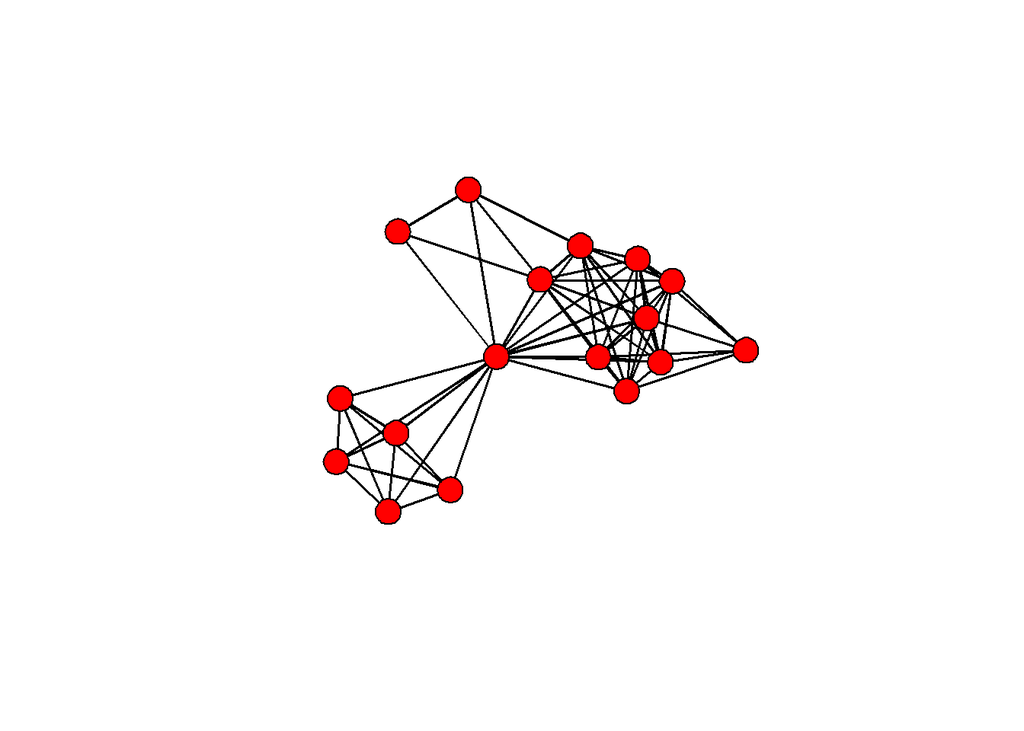

```r
mycoords1 <- gplot(Bali,gmode="graph",vertex.cex=1.5)
```

```r
mycoords1
```

```
##                x        y
##  [1,]  1.9580078 7.046200
##  [2,] -0.4832577 8.267901
##  [3,]  3.9606251 6.273290
##  [4,]  0.1269099 4.627523
##  [5,]  3.2068902 6.759471
##  [6,]  1.0850017 6.309809
##  [7,] -2.0209784 7.357134
##  [8,]  3.7056897 4.506155
##  [9,]  3.4048080 5.471950
## [10,] -3.3667502 2.337306
## [11,] -2.0631879 2.959200
## [12,] -0.8766032 1.721728
## [13,] -3.2800680 3.714031
## [14,] -2.2341703 1.247578
## [15,]  2.3499912 4.618900
## [16,]  5.5696135 4.768781
## [17,]  2.9699287 3.876400
```

```r
mycoords2 <- mycoords1
mycoords2[,2] <- mycoords1[,2]*1.5
mycoords2
```

```
##                x         y
##  [1,]  1.9580078 10.569300
##  [2,] -0.4832577 12.401852
##  [3,]  3.9606251  9.409935
##  [4,]  0.1269099  6.941284
##  [5,]  3.2068902 10.139207
##  [6,]  1.0850017  9.464713
##  [7,] -2.0209784 11.035701
##  [8,]  3.7056897  6.759232
##  [9,]  3.4048080  8.207925
## [10,] -3.3667502  3.505960
## [11,] -2.0631879  4.438800
## [12,] -0.8766032  2.582593
## [13,] -3.2800680  5.571047
## [14,] -2.2341703  1.871368
## [15,]  2.3499912  6.928351
## [16,]  5.5696135  7.153171
## [17,]  2.9699287  5.814600
```

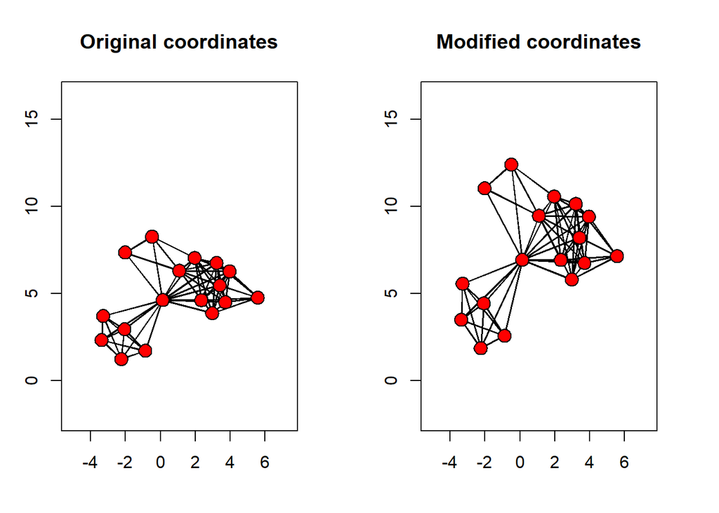

```r
op <- par(mar=c(4,3,4,3),mfrow=c(1,2))

gplot(Bali,gmode="graph",vertex.cex=1.5,
      coord=mycoords1, suppress.axes = FALSE,
      ylim=c(min(mycoords2[,2])-1,max(mycoords2[,2])+1),
      main="Original coordinates")

gplot(Bali,gmode="graph",vertex.cex=1.5,
      coord=mycoords2,suppress.axes = FALSE,
      ylim=c(min(mycoords2[,2])-1,max(mycoords2[,2])+1),
      main="Modified coordinates")
```

```r
par(op)
```

#### **Metode de plotare folosind libraria *igraph***

Libraria **igraph** ne ofera optiuni similare in ceea ce priveste layout-ul graficului. Parametru **layout** al functiei **plot** este util.

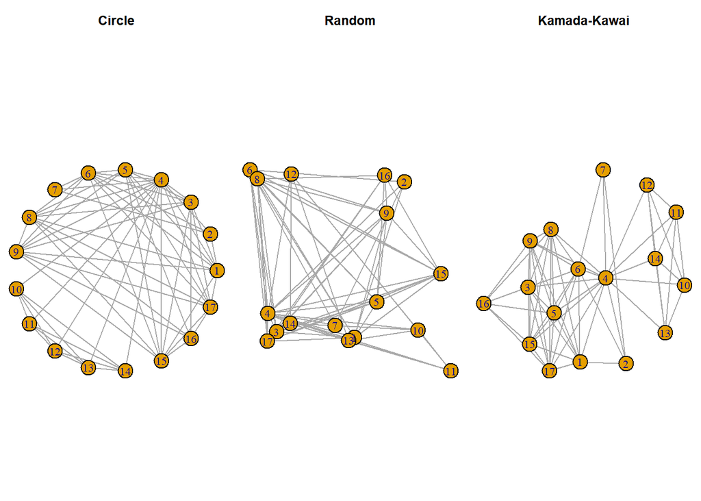

```r
iBali <- asIgraph(Bali)
op <- par(mar=c(0,0,3,0),mfrow=c(1,3))
plot(iBali,layout=layout_in_circle,main="Circle")
plot(iBali,layout=layout_randomly,main="Random")
plot(iBali,layout=layout_with_kk,main="Kamada-Kawai")
```

```r
par(op)
```

## **2. Design sugestiv in realizarea graficelor**

Obiectivul principal al unui design eficace este de a dezvalui trasaturile importante ale unei retele si informatia continuta in aceasta. Pentru atingerea acestui scop, librariile *statnet* si *igraph* ofera control programatic asupra aspectului oricarui element din graficul retelei.

> Excelenta in design-ul grafic presupune transmiterea unui numar cat mai mare de idei intr-un timp cat mai scurt, folosind cat mai putina cerneala si spatiu. - Edward Tufte

Un grafic al unei retele contine o multitudine de elemente (noduri, legaturi) dar si elemente care se regasesc in orice tip de grafic (titluri, legende, etc.). Alegerea unor caracteristici potrivite pentru aceste elemente se face respectand principiile estetice, dar ele difera in functie de “povestea” pe care analistul vrea sa o transmita.

### **Culoarea nodurilor**

Implicit, *statnet* foloseste cercuri de culoare rosie pentru a reprezenta nodurile retelei. Culoarea nodurilor se poate configura prin optiunea **vertex.col** a functiei **gplot**. Optiunea *gmode* este “graph” pentru a nu interpreta graful ca fiind orientat.

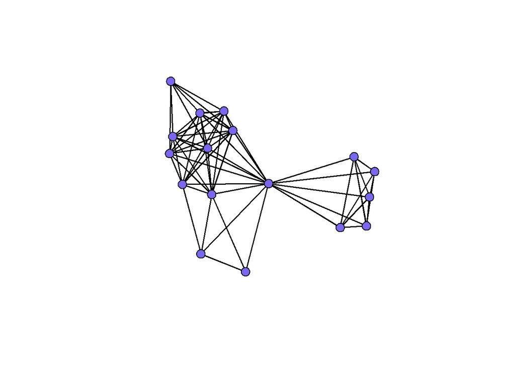

```r
gplot(Bali,vertex.col="slateblue2",gmode="graph")
```

R ofera 657 de culori, care pot fi consultate folosind functia **colors()**. De asemenea, culorile se pot crea cu ajutorul functiei **rgb**, dar pot fi definite si ca stringuri formate din caractere hexazecimale (**#RRGGBB**). Functia **col2rgb** transforma o culoare predefinita (din colors()) intr-un triplet de intensitati.

```r
col2rgb('slateblue2')
```

```
##       [,1]
## red    122
## green  103
## blue   238
```

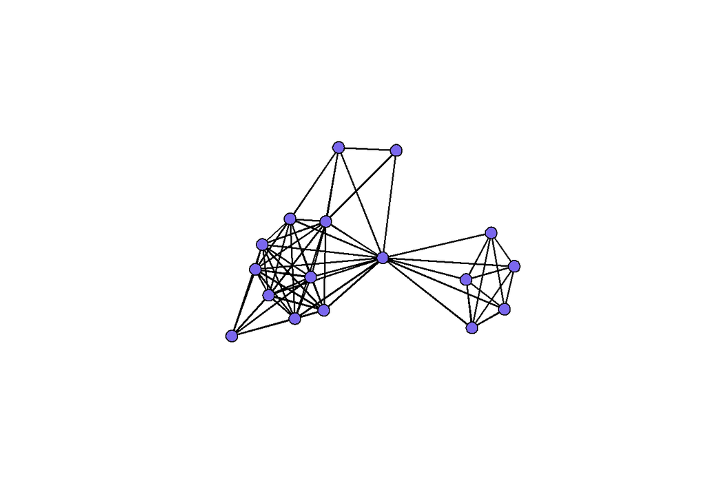

```r
gplot(Bali,vertex.col=rgb(122,103,238,maxColorValue=255),gmode="graph")
```

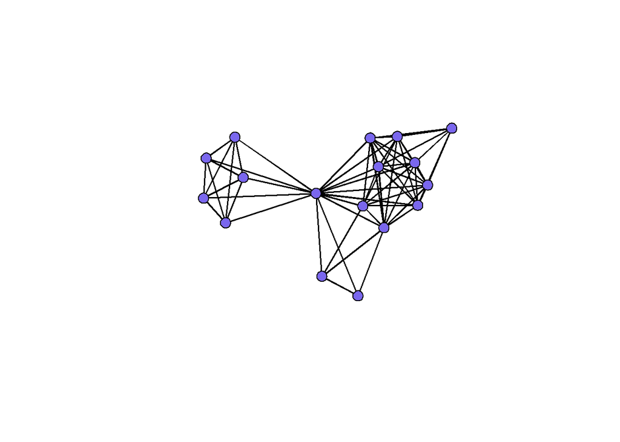

```r
gplot(Bali,vertex.col="#7A67EE",gmode="graph")
```

De asemenea, functia **rgb** mai are si optiunea **alpha** care reprezinta transparenta nodurilor. Intr-un graf cu foarte multe noduri, acestea pot fi greu de distins daca se suprapun unele peste altele. Daca culorile sunt transparente, graficul e mai usor de inteles.

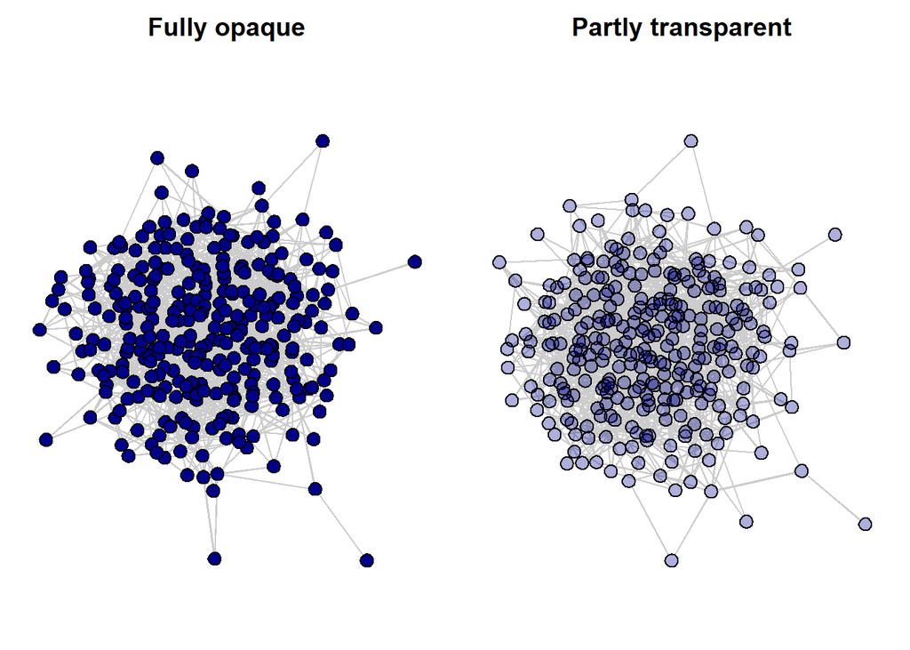

```r
ndum <- rgraph(300,tprob=0.025,mode="graph")

op <- par(mar = c(0,0,2,0),mfrow=c(1,2))

gplot(ndum,gmode="graph",
      vertex.cex=2, vertex.col=rgb(0,0,139,maxColorValue=255),
      edge.col="grey80",edge.lwd=0.5,
      main="Fully opaque")

gplot(ndum,gmode="graph",
      vertex.cex=2,vertex.col=rgb(0,0,139,alpha=80,maxColorValue=255),
      edge.col="grey80",edge.lwd=0.5,
      main="Partly transparent")
```

```r
par(op)
```

In exemplele anterioare, toate nodurile aveau aceeasi culoare. Totusi, culori diferite se pot atribui nodurilor pentru a comunica o caracteristica a acestora, apartenenta la o anumita categorie.

De exemplu, reteaua Bali contine atributul *role* pentru fiecare nod, care reprezinta rolul fiecarui membru in gruparea terorita (BM - bomb maker, CT - command team, etc.). Reprezentarea fiecarui rol cu o culoare diferita poate ilustra mai bine informatia din interiorul retelei.

Acest lucru se realizeaza prin specificarea atributului categoric (*role*, in cazul acesta) al nodurilor pentru optiunea **vertex.col** atunci cand se foloseste functia **plot**.

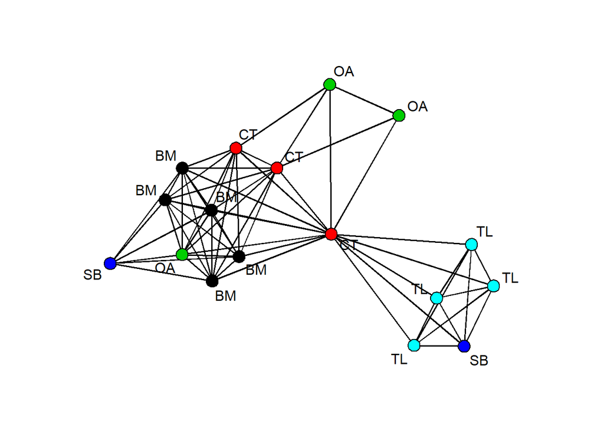

```r
rolelab <- get.vertex.attribute(Bali,"role")
op <- par(mar=c(0,0,0,0))
plot(Bali,usearrows=FALSE,vertex.cex=1.5,label=rolelab,displaylabels=T,vertex.col="role")
```

```r
par(op)
```

Optiunea **label** reprezinta textele asociate fiecarui nod, iar acestea sunt luate din vectorul de roluri.

Graficul este mai usor de interpretat acum, se pot observa mici subgrupuri (TL si BM). Totusi, culorile de mai sus sunt luate implicit din paleta de culori din R.

```r
palette()
```

```
## [1] "black"   "red"     "green3"  "blue"    "cyan"    "magenta" "yellow"
## [8] "gray"
```

Aceasta paleta de culori are cateva dezavantaje. Este limitata la 8 culori iar culorile incluse nu sunt sugestive in realizarea unui grafic. O alternativa mai buna este definirea unei palete de culori custom, cu ajutorul librariei *RColorBrewer*.

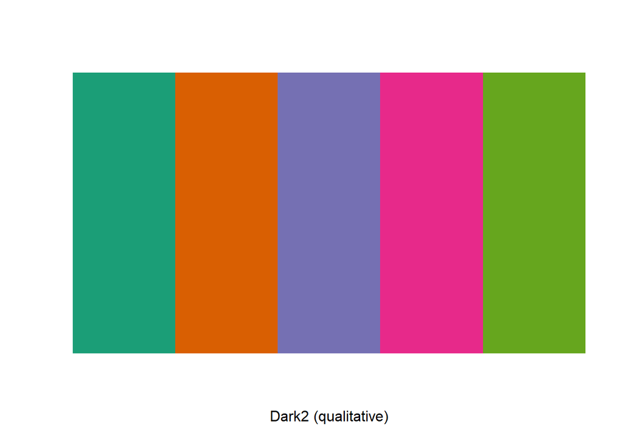

```r
library(RColorBrewer)
display.brewer.pal(5, "Dark2")
```

Acestea sunt 5 culori alese dintr-o paleta mai larga numita *Dark2*. Culorile sunt mai placute decat cele din paleta default. Pentru a crea un grafic folosind aceasta paleta de culori, se procedeaza in felul urmator:

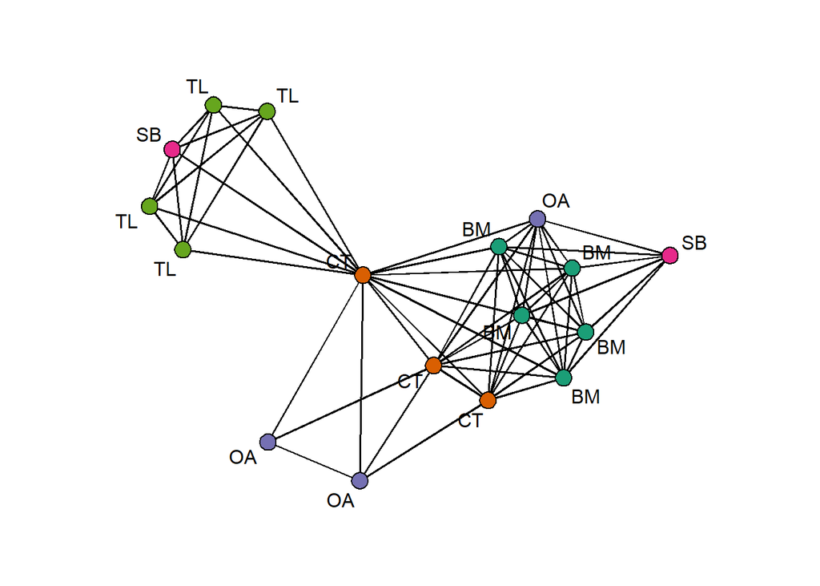

```r
op <- par(mar=c(0,0,0,0))
my_pal <- brewer.pal(5,"Dark2")
rolecat <- as.factor(get.vertex.attribute(Bali,"role"))
plot(Bali,vertex.cex=1.5,label=rolelab,displaylabels=T,vertex.col=my_pal[rolecat])
```

```r
par(op)
```

Pentru a putea folosi atributul *role* acesta trebuie castat intr-un *factor* si apoi pasat functiei **plot**.

### **Forma nodurilor**

Pe langa culoarea nodurilor, putem controla si forma lor. Acest lucru e util atunci cand sunt putine categorii de noduri. De asemenea, este folositor pentru persoanele care nu pot distinge culori. In libraria *statnet*, nodurile sunt practic poligoane, iar singurul lucru configurabil este numarul de laturi (3 - triunghi, 4 - patrat, etc.).

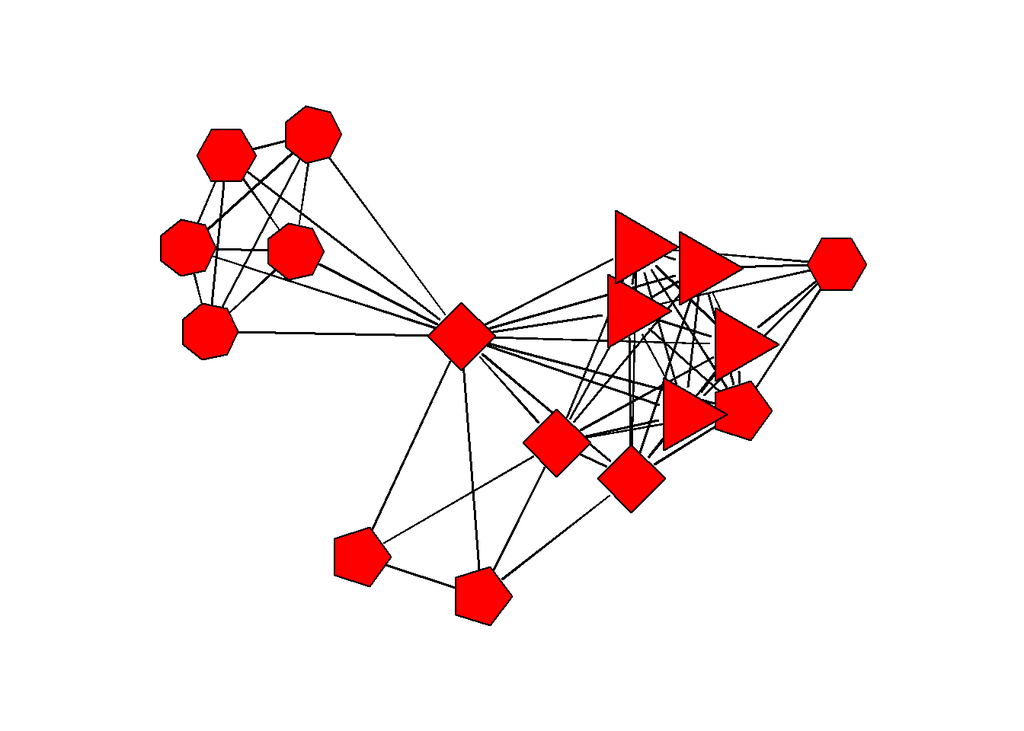

```r
op <- par(mar=c(0,0,0,0))
sidenum <- 3:7
plot(Bali,usearrows=FALSE,vertex.cex=4,displaylabels=F,vertex.sides=sidenum[rolecat])
```

```r
par(op)
```

### **Marimea nodurilor**

Marimea nodurilor este controlata prin optiunea **vertex.cex** a functiilor *gplot* si *plot*.

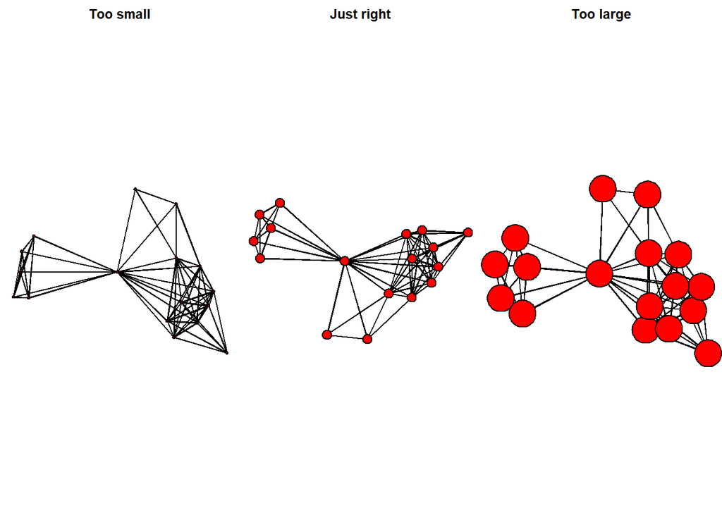

```r
op <- par(mar = c(0,0,2,0),mfrow=c(1,3))
plot(Bali,vertex.cex=0.5,main="Too small")
plot(Bali,vertex.cex=2,main="Just right")
plot(Bali,vertex.cex=6,main="Too large")
```

```r
par(op)
```

Mai interesanta este reprezentarea nodurilor prin **marimi diferite** penru a reliefa o **caracteristica cantitativa**. Cum nodurile din reteaua Bali nu au un atribut cantitativ, vom simula unul. O valoare mai mare a acestui atribut (numar) inseamna ca nodul este mai central. Pentru a masura centralitatea unui nod, ne vom folosi de trei masuri diferite.

```r
deg <- degree(Bali,gmode="graph")
deg
```

```
##  [1]  9  4  9 15  9 10  3  9  9  5  5  5  5  5  9  6  9
```

```r
cls <- closeness(Bali,gmode="graph")
cls
```

```
##  [1] 0.6956522 0.5517241 0.6956522 0.9411765 0.6956522 0.7272727 0.5333333
##  [8] 0.6956522 0.6956522 0.5714286 0.5714286 0.5714286 0.5714286 0.5714286
## [15] 0.6956522 0.4848485 0.6956522
```

```r
bet <- betweenness(Bali,gmode="graph")
bet
```

```
##  [1]  2.3333333  0.3333333  1.6666667 61.1666667  1.6666667  6.1666667
##  [7]  0.0000000  1.6666667  1.6666667  0.0000000  0.0000000  0.0000000
## [13]  0.0000000  0.0000000  1.6666667  0.0000000  1.6666667
```

Vectorii rezultati contin, pentru fiecare nod, o marime relativa. In cazul primului vector **deg** care contine gradul fiecarui nod, valorile sunt prea mari, asa ca vom calcula logaritmul fiecare valori folosind functia **log**.

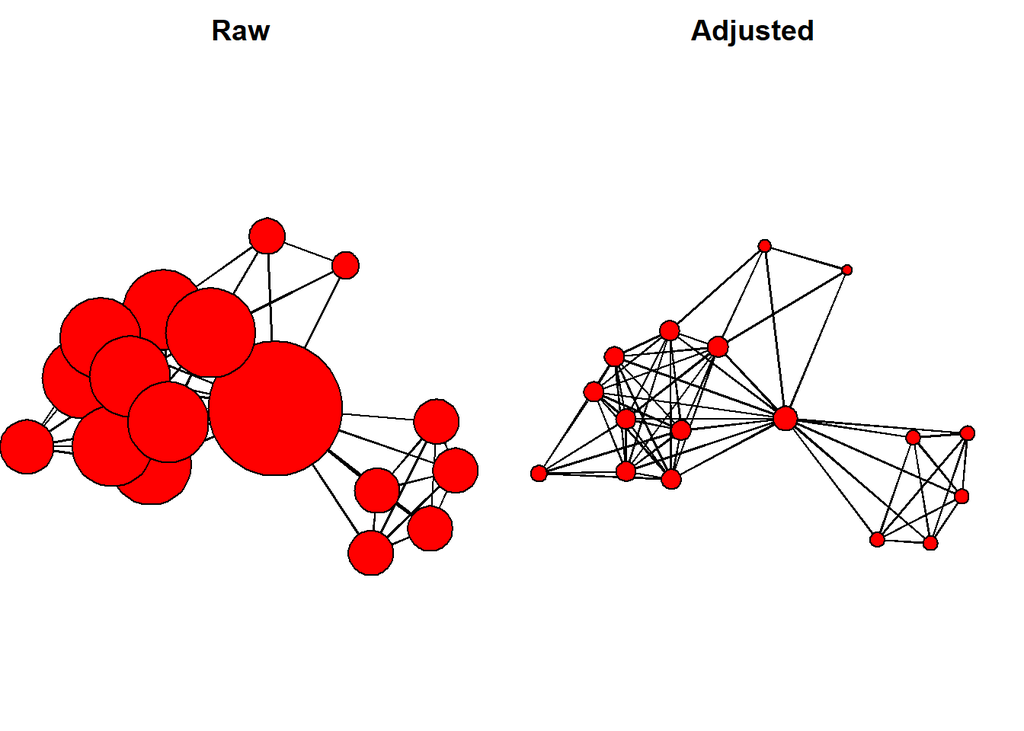

```r
op <- par(mar = c(0,0,2,1),mfrow=c(1,2))
plot(Bali,usearrows=T,vertex.cex=deg,main="Raw")
plot(Bali,usearrows=FALSE,vertex.cex=log(deg),main="Adjusted")
```

```r
par(op)
```

Urmatoarele doua exemple necesita alt tip de ajustari. Pentru vectorul **cls** valorile sunt prea mici, iar nodurile retelelei nu vor fi vizibile. In consecinta, vom inmulti toate valorile cu 4. Pentru vectorul **bet**, unele valori sunt foarte mari, iar altele foarte mici, unele fiind chiar 0. Pentru a obtile marimile potrivite, vom aduna 1 si apoi vom calcula radacina patrata a fiecarui numar.

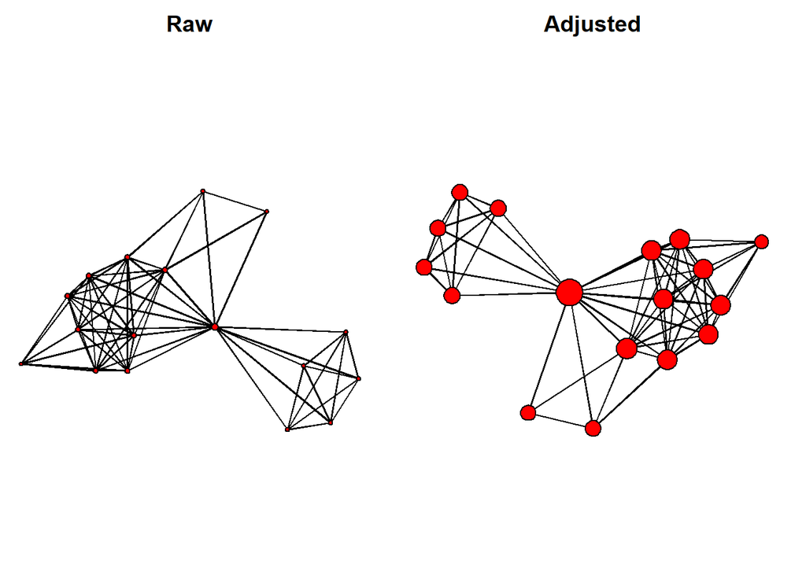

```r
op <- par(mar = c(0,0,2,1),mfrow=c(1,2))
plot(Bali,usearrows=T,vertex.cex=cls,main="Raw")
plot(Bali,usearrows=FALSE,vertex.cex=4*cls,main="Adjusted")
```

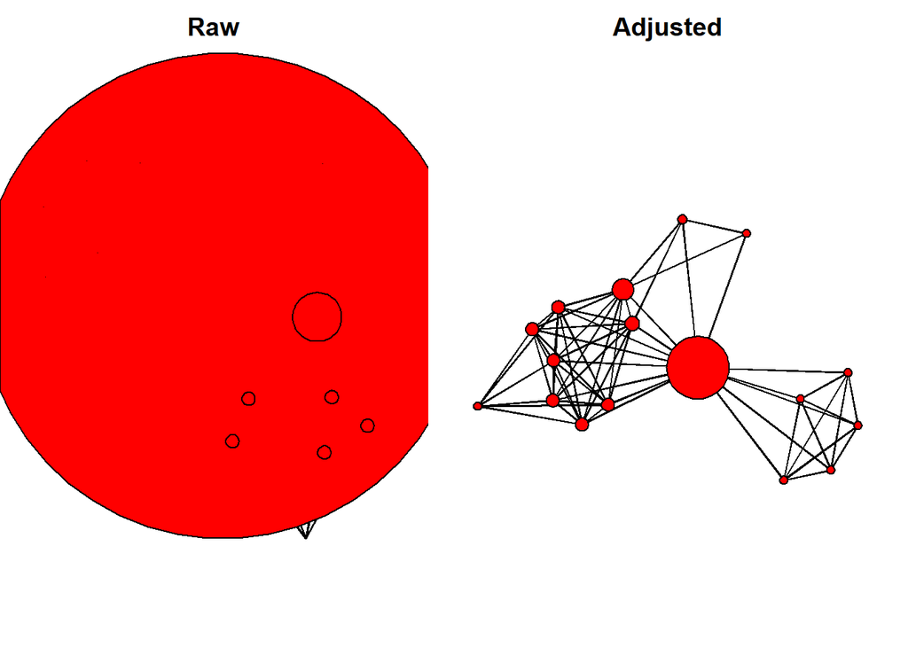

```r
par(op)

op <- par(mar = c(0,0,2,1),mfrow=c(1,2))
plot(Bali,usearrows=T,vertex.cex=bet,main="Raw")
plot(Bali,usearrows=FALSE,vertex.cex=sqrt(bet+1),main="Adjusted")
```

```r
par(op)
```

Aceste ajustari manuale pot fi obositoare. O functie utila pentru a ajusta valorile unui vector este urmatoarea:

```r
rescale <- function(nchar,low,high) {
  min_d <- min(nchar)
  max_d <- max(nchar)
  rscl <- ((high-low)*(nchar-min_d))/(max_d-min_d)+low
  rscl
}
```

Functia **rescale** primeste un vector de numere si valorile *low* si *high*. La final, fiecare numar se va gasi in intervalul [low,high].

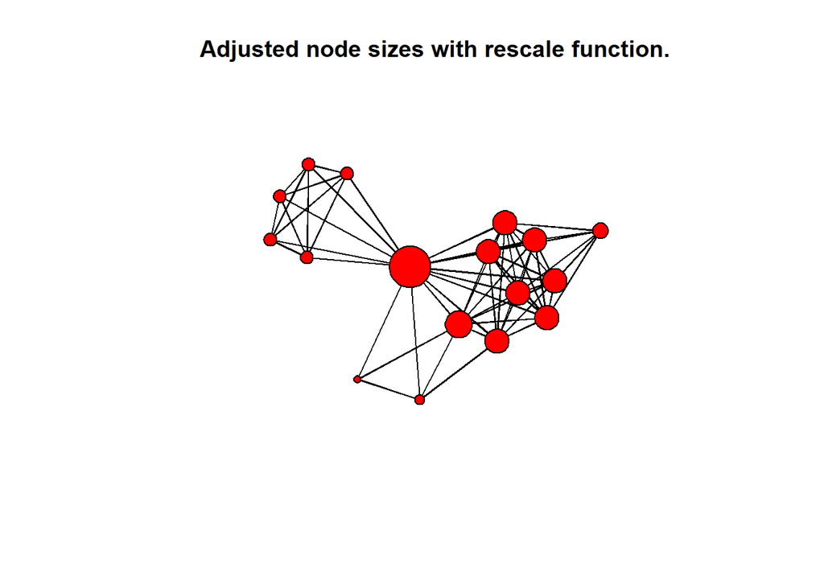

```r
plot(Bali,vertex.cex=rescale(deg,1,6),main="Adjusted node sizes with rescale function.")
```

### **Etichete ale nodurilor**

Un grafic este mai usor de inteles daca fiecare nod are o **eticheta asociata**. Totusi, daca numarul de noduri este prea mare, aceasta tehnica isi pierde eficienta si chiar dauneaza expresivitatii graficului.

Daca un obiect de tip retea din libraria *statnet* contine atributul *vertex.names* pentru noduri, acesta poate fi folosit pentru a afisa automat etichetele cand se ploteaza graficul. De asemenea, alte caracteristici ale etichetele pot fi controlate: marimea textului, culoarea, distanta fata de nodul asociat, etc.

```r
get.vertex.attribute(Bali,"vertex.names")
```

```
##  [1] "Muklas"   "Amrozi"   "Imron"    "Samudra"  "Dulmatin" "Idris"
##  [7] "Mubarok"  "Husin"    "Ghoni"    "Arnasan"  "Rauf"     "Octavia"
## [13] "Hidayat"  "Junaedi"  "Patek"    "Feri"     "Sarijo"
```

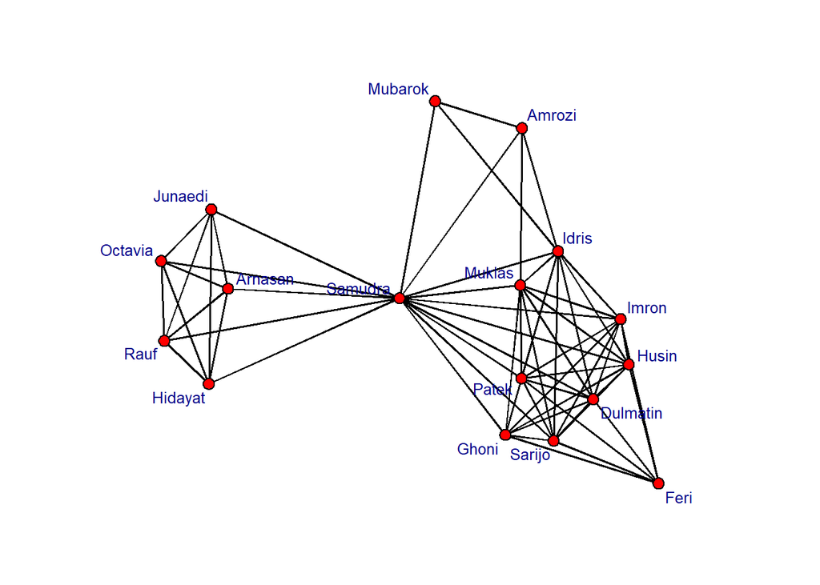

```r
op <- par(mar = c(0,0,0,0))
plot(Bali,displaylabels=TRUE,label.cex=0.8,pad=0.4,label.col="darkblue")
```

```r
par(op)
```

Valorile din vectorul *vertex.names* pot fi irelevante. Din fericire, putem folosi alt atribut pentru valorile etichetelor. In cazul retelei Bali, atributul *role* ofera mai multa informatie decat numele membrilor.

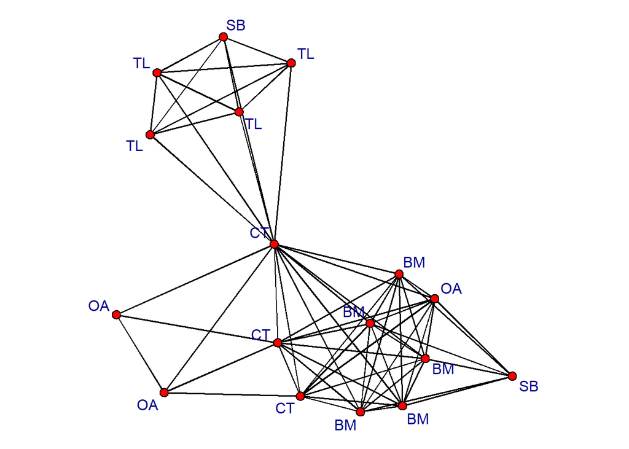

```r
op <- par(mar = c(0,0,0,0))
rolelab <- get.vertex.attribute(Bali,"role")
plot(Bali,usearrows=FALSE,label=rolelab,displaylabels=T,label.col="darkblue")
```

```r
par(op)
```

### **Grosimea muchiilor**

Daca reteaua contine legaturi care au asociate valori cantitative, atunci acestea pot fi reprezentate prin grosimea unei muchii. De exemplu, gradul de intensitate al unei prietenii, marimea sumei de bani dintr-o tranzactie financiara, sunt informatii care pot contribui la grosimea unei muchii.

Reteaua Bali contine un atribut pentru fiecare muchie, numit **IC**, care simbolizeaza gradul de interactiune dintre cei doi membri ai retelei. Muchiile mai groase reprezinta relatii mai puternice.

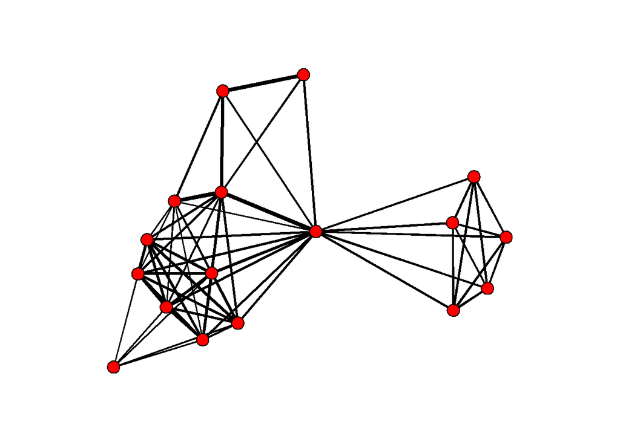

```r
op <- par(mar = c(0,0,0,0))
IClevel <- Bali %e% "IC"
plot(Bali,vertex.cex=1.5,edge.lwd=1.5*IClevel)
```

```r
par(op)
```

### **Culoarea muchiilor**

Spre deosebire de grosimea unei muchii, care transmite o valoare cantitativa, culoarea unei muchii comunica o valoare calitativa a legaturii dintre cele doua noduri. Spre exemplu, intr-o retea sociala, muchiile verzi pot insemna prietenii, muchiile gri neutralitate iar muchiile rosii dusmanii.

Reteaua Bali nu contine o valoare calitativa asociata muchiilor, asa ca vom crea noi una, pentru a oferi un exemplu.

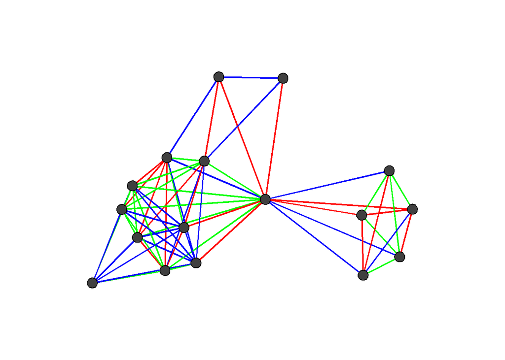

```r
op <- par(mar = c(0,0,0,0))

n_edge <- network.edgecount(Bali)
edge_cat <- sample(1:3,n_edge,replace=T)
linecol_pal <- c("blue","red","green")

plot(Bali,vertex.cex=1.5,vertex.col="grey25",
     edge.col=linecol_pal[edge_cat],
     edge.lwd=2)
```

```r
par(op)
```

### **Tipul muchiilor**

Asemanator culorii unei muchii, tipul acesteia poate comunica informatii calitative. Mergand pe acelasi exemplu, vom simula un atribut al muchiilor si vom plota folosind diferita tipuri de muchii (2-linie intrerupta; 3-linie punctata; 4-linie punctata si intrerupta).

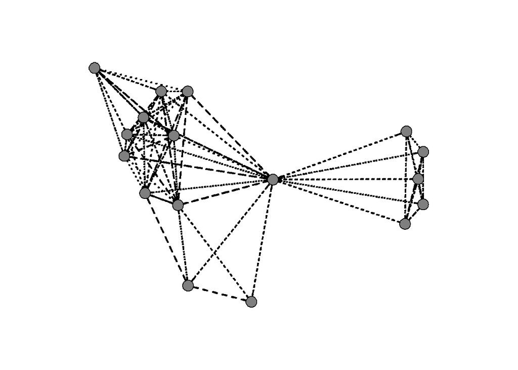

```r
op <- par(mar = c(0,0,0,0))

n_edge <- network.edgecount(Bali)
edge_cat <- sample(1:3,n_edge,replace=T)
line_pal <- c(2,3,4)

gplot(Bali,vertex.cex=0.8,gmode="graph",vertex.col="gray50",
      edge.lwd=1.5,
      edge.lty=line_pal[edge_cat])
```

```r
par(op)
```

Cu toate ca exemplul de mai sus functioneaza, nu este prea estetic. Folosirea unor tipuri diferite de muchii este recomandata doar pentru retele foarte mici, ce contin doar doua-trei tipuri de muchii.

### **Legende**

O legenda are rolul de a clarifica informatiile continute in grafic. Functiile de baza de plotare din *statnet* nu ofera aceasta functionalitate, dar putem folosi functia **legend()** din limbajul R.

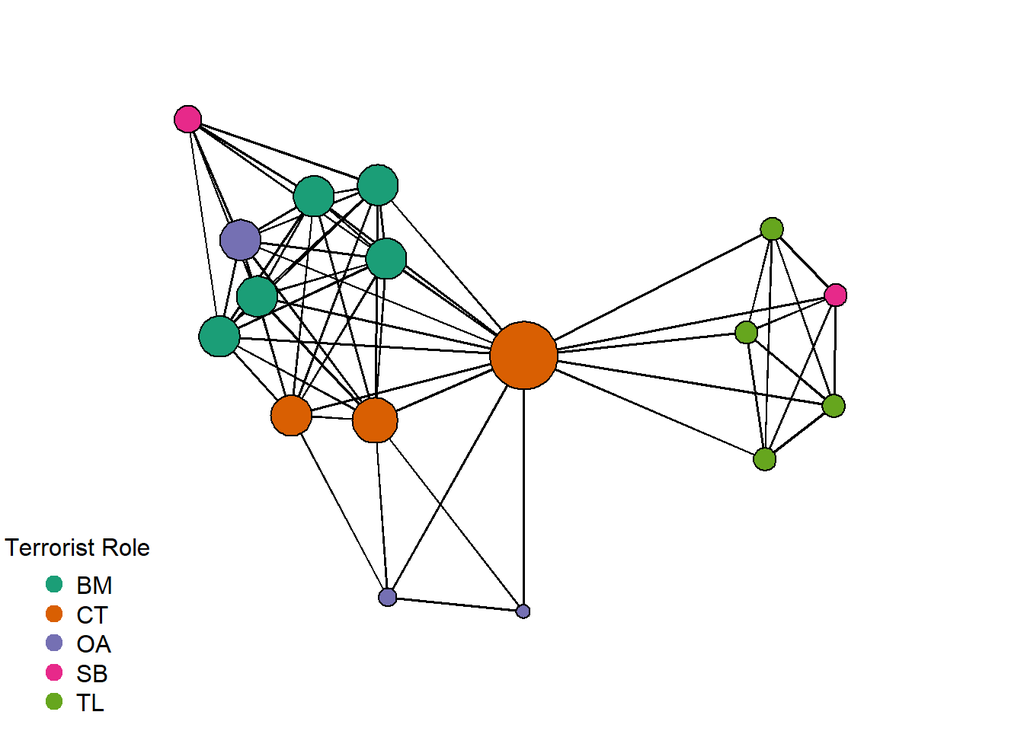

```r
op <- par(mar = c(0,0,0,0))

my_pal <- brewer.pal(5,"Dark2")
rolecat <- as.factor(get.vertex.attribute(Bali,"role"))

plot(Bali,vertex.cex=rescale(deg,1,5),vertex.col=my_pal[rolecat])

legend("bottomleft",
       legend=c("BM","CT","OA","SB","TL"),
       col=my_pal,
       pch=19,
       pt.cex=1.5,
       bty="n",
       title="Terrorist Role")
```

```r
par(op)
```

## **3. Tehnici avansate de plotare a graficelor**

Graficele realizate pana acum, cu ajutorul librariilor *statnet* si *igraph* au fost statice. Pentru reprezentarea mai specializata a unor retele, avem nevoie de interactiune. Din fericire, dezvoltatorii au inceput sa exploreze aceasta ramura, iar progresele sunt semnificative.

### **Retele interactive simple in *igraph***

Pachetul *igraph* ofera functia **tkplot()**, prin care se poate configura fiecare element al unui grafic, intr-o maniera interactiva. Un mod tipic de utilizare a acestei functii este urmatorul:

1. se creeaza fereastra interactiva care contine elementele graficului
2. se ajusteaza caracteristicile nodurilor (locatie, culoare)
3. se modifica (optional) caracteristicile muchiilor (culoare, tip, grosime)
4. se preiau setarile din fereastra si se creeaza noul grafic

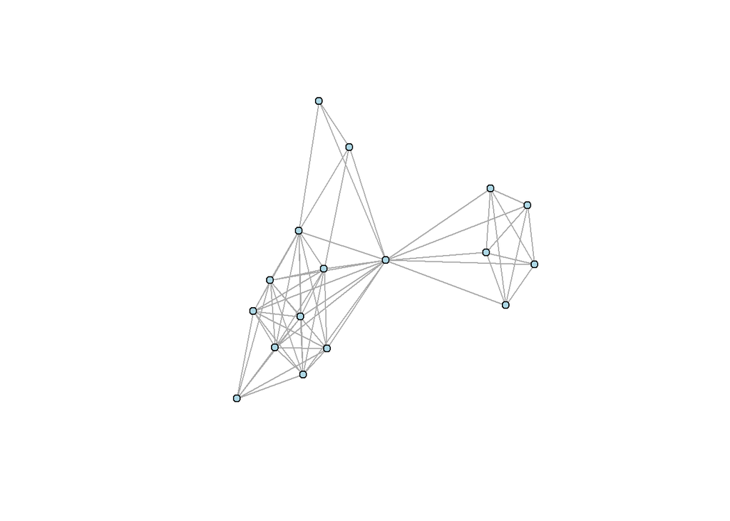

```r
iBali <- asIgraph(Bali)
Coord <- tkplot(iBali, vertex.size=3,
                vertex.label=V(iBali)$role,
                vertex.color="darkgreen")

# Edit plot in Tk graphics window before
# running next two commands.
MCoords <- tkplot.getcoords(Coord)
plot(iBali, layout=MCoords, vertex.size=5,vertex.label=NA, vertex.color="lightblue")
```

### **Diagrame interactive web-based**

Folosind pachetul **networkD3** putem construi grafice interactive care pot fi afisate in documente *shiny-aware* sau in documente *HTML*. In urmatorul exemplu, vom vedea cat de simpla e realizarea unui astfel de grafic. Functia **simpleNetwork()** primeste datele retelei printr-o lista de adiacenta stocata intr-un *data frame*.

```r
library(networkD3)
src <- c("A","A","B","B","C","E")
target <- c("B","C","C","D","B","C")
net_edge <- data.frame(src, target)
simpleNetwork(net_edge)
```

[interactive chart not shown]

Pentru a salva graficul intr-un document *HTML* de sine statator, se foloseste functia **saveNetwork**.

```r
net_D3 <- simpleNetwork(net_edge)
saveNetwork(net_D3,file = 'Net_test1.html',selfcontained=TRUE)
```

Exemplul de mai sus este extrem de simplu. Un grafic interactiv mai complex poate fi realizat cu ajutorul functiei **forceNetwork()**. Cateva reguli in ceea ce priveste aceasta functie:

- datele retelei sunt pasate prin **doua data frame-uri**: *links* si *nodes*
- **links** va contine legaturile intr-o lista de adiacenta
- **nodes** va contine nodurile. Prima coloana este id-ul nodului iar apoi proprietatile lui. Id-urile incep de la 0.

```r
iBali_edge <- get.edgelist(iBali)
iBali_edge <- iBali_edge - 1
iBali_edge <- data.frame(iBali_edge)

iBali_nodes <- data.frame(NodeID=as.numeric(V(iBali)-1),
                          Group=V(iBali)$role,
                          Nodesize=(degree(iBali)))

forceNetwork(Links = iBali_edge,
             Nodes = iBali_nodes,
             Source = "X1", Target = "X2",
             NodeID = "NodeID", Nodesize = "Nodesize",
             radiusCalculation="Math.sqrt(d.nodesize)*3",
             Group = "Group", opacity = 0.8,
             legend=TRUE)
```

[interactive chart not shown]

Pachetul **visNetwork** ofera functionalitati similare pentru realizarea graficelor interactive, fiind bazat pe libraria javascript *vis.js*.

```r
iBali_edge <- get.edgelist(iBali)
iBali_edge <- data.frame(from = iBali_edge[,1],to = iBali_edge[,2])

iBali_nodes <- data.frame(id = as.numeric(V(iBali)))

visNetwork(iBali_nodes, iBali_edge, width = "100%")
```

[interactive chart not shown]

### **Diagrame specializate**

Pana recent, graficele retelelor au fost proiectate pentru a ilustra caracteristici fundamentale ale retelei si a nodurilor, cum ar fi importanta acestora. Totusi, exista tehnici de plotare mai specializate al caror scop este sa evidentieze alte aspecte interesante ale unei retele. Trei dintre acestea vor fi prezentate in continuare:

- Diagrame de tip *arc*
- Diagrame de tip *chord*
- Heatmaps

#### **Diagrame de tip *arc***

Acest tip de diagrame pot fi folosite atunci cand vrem sa punem accentul pe relatiile dintre noduri, si nu pe pozitionarea acestora. Ca exemplu, vom folosi *dataset-ul* **Simpsons** care contine date despre interactiunile dintre personajele serialului Simpsons. Un simplu grafic de tip *arc* este urmatorul:

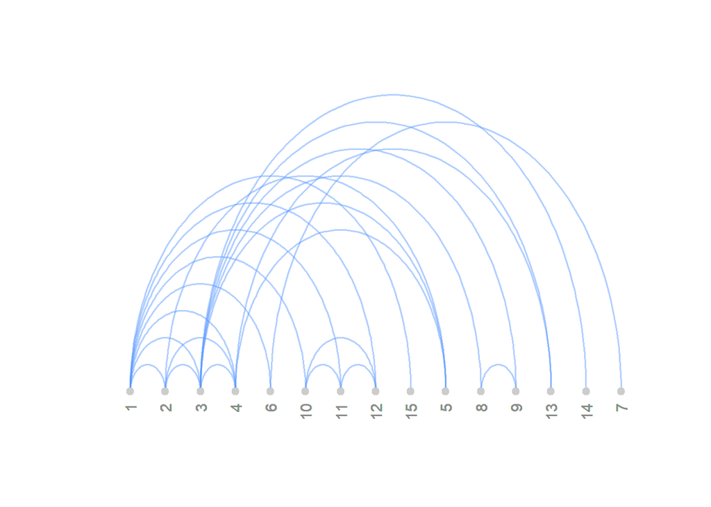

```r
data(Simpsons)
iSimp <- asIgraph(Simpsons)
simp_edge <- get.edgelist(iSimp)
arcplot(simp_edge)
```

Pentru a augmenta acest grafic, vom defini cateva subgrupuri in retea (1-familie; 2-colegi de munca; 3-colegi de scoala; 4-vecini) si vom folosi culori diferite pentru a distinge intre aceste categorii. De asemenea, folosim gradul unui nod pentru a obtine marimea acestuia.

[figure not shown]

```r
s_grp <- V(iSimp)$group
s_col = c("#a6611a", "#dfc27d","#80cdc1","#018571")
cols = s_col[s_grp]
node_deg <- degree(iSimp)

arcplot(simp_edge,
        lwd.arcs=2,
        cex.nodes=node_deg/2,
        labels=V(iSimp)$vertex.names,
        col.labels="darkgreen",
        font=1,
        pch.nodes=21,
        line=1,
        col.nodes = cols,
        bg.nodes = cols,
        show.nodes = TRUE)
```

#### **Diagrame de tip *chord***

Acest tip de diagrame specializate folosesc un layout circular care evidentiaza inter-relatiile dintre datele stocate intr-o matrice. Sunt foarte populare in domeniul cercetarii genetice. Sunt potrivite, in special, pentru grafuri orientate si cu costuri, unde directia si cantitatea flow-urilor de date este de interes.

Pentru realizarea unui astfel de grafic vom folosi pachetul **circlize**. Ca exemplu, vom lua echipa de fotbal a Olandei din Campionatul Mondial din 2010. Pentru inceput, vom analiza **pasele** dintre cei 11 jucatori.

```r
data(FIFA_Nether)
FIFAm <- as.sociomatrix(FIFA_Nether,attrname='passes')
names <- c("GK1","DF3","DF4","DF5","MF6","FW7","FW9","MF10","FW11","DF2","MF8")
rownames(FIFAm) = names
colnames(FIFAm) = names
FIFAm
```

```
##      GK1 DF3 DF4 DF5 MF6 FW7 FW9 MF10 FW11 DF2 MF8
## GK1    0  42  67  21   2  27   7    5    2  17   3
## DF3   30   0  44  14  42  15   8    7   10  36  29
## DF4   38  43   0  57  18  11   7   21    1   7  28
## DF5    6  14  47   0  11  50  20   40    1   4  42
## MF6    9  28  25  10   0  41  28   37   14  34  21
## FW7    4  12   1  21  21   0  15   33    9  25  18
## FW9    0   0   1   8   7  12   0   31   16   7   2
## MF10   1  11  11  22  43  29  20    0   28  13  21
## FW11   3   2   2   3   7   6  11   15    0  21  12
## DF2   29  38   8   3  45  38  10   18   26   0  15
## MF8   12  25  26  38  23  13  12   32   11  24   0
```

Pentru ca graficul sa nu fie greu de citit, vom renunta la legaturile care au mai putin de 10 pase.

```r
FIFAm[FIFAm < 10] <- 0
FIFAm
```

```
##      GK1 DF3 DF4 DF5 MF6 FW7 FW9 MF10 FW11 DF2 MF8
## GK1    0  42  67  21   0  27   0    0    0  17   0
## DF3   30   0  44  14  42  15   0    0   10  36  29
## DF4   38  43   0  57  18  11   0   21    0   0  28
## DF5    0  14  47   0  11  50  20   40    0   0  42
## MF6    0  28  25  10   0  41  28   37   14  34  21
## FW7    0  12   0  21  21   0  15   33    0  25  18
## FW9    0   0   0   0   0  12   0   31   16   0   0
## MF10   0  11  11  22  43  29  20    0   28  13  21
## FW11   0   0   0   0   0   0  11   15    0  21  12
## DF2   29  38   0   0  45  38  10   18   26   0  15
## MF8   12  25  26  38  23  13  12   32   11  24   0
```

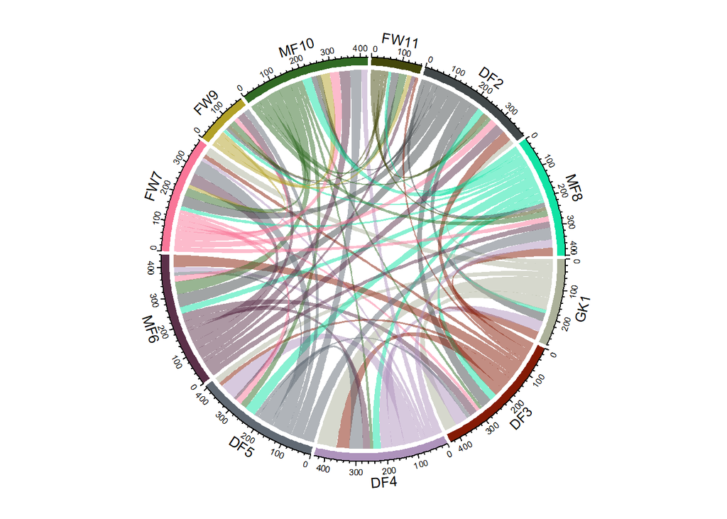

```r
chordDiagram(FIFAm)
```

Pentru a face graficul si mai sugestiv, vom modifica urmatoarele lucruri:

- jucatorii de pe aceeasi pozitie vor avea aceeasi culoare.
- optiunea *directional* face ca pasele care pleaca de la jucator sa inceapa mai departe de cercul exterior, facand usoara observarea diferentei dintre pasele date si cele primite.
- optiunea *order* sorteaza jucatorii in functie de pozitia acestora.

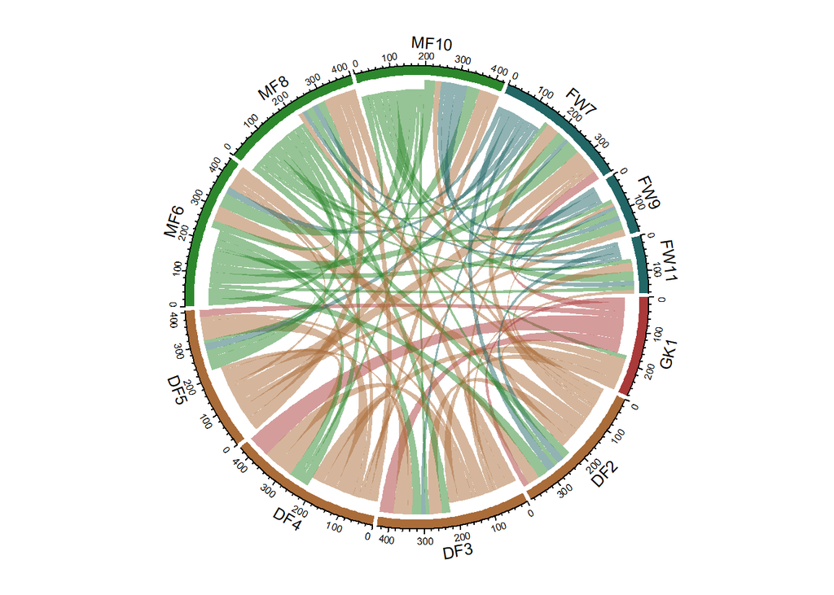

```r
grid.col <- c("#AA3939",rep("#AA6C39",4),rep("#2D882D",3),rep("#226666",3))
chordDiagram(FIFAm,
             directional = TRUE,
             grid.col = grid.col,
             order=c("GK1","DF2","DF3","DF4","DF5","MF6","MF8","MF10","FW7","FW9","FW11"))
```

Acum se pot observa mai usor tiparele paselor. De exemplu, atacantul FW7 primeste de doua ori mai multe pase fata de ceilalti doi atacanti. Asemanator, putem observa ca coechipierul favorit al portarului GK1 este fundasul DF4, iar DF4 da pase frecvent la DF5.

#### **Heatmaps**

Acestea sunt o alta varianta de grafice specializate, utile, in special, atunci cand reteaua are costuri. In exemplul urmator, un astfel de grafic va evidentia jucatorii care ofera si primesc cele mai multe pase.

```r
data(FIFA_Nether)
FIFAm <- as.sociomatrix(FIFA_Nether,attrname='passes')
colnames(FIFAm) <- c("GK1","DF3","DF4","DF5","MF6","FW7","FW9","MF10","FW11","DF2","MF8")
rownames(FIFAm) <- c("GK1","DF3","DF4","DF5","MF6","FW7","FW9","MF10","FW11","DF2","MF8")
```

Functia **colorRampPalette()** e folosita pentru a asigna o paleta de culori cu valori intre valoarea maxima din matrice si cea minima. Reteaua fiind una orientata, consideram ca jucatorii care **dau pase** sunt randurile, iar coloanele sunt jucatorii care primesc pase.

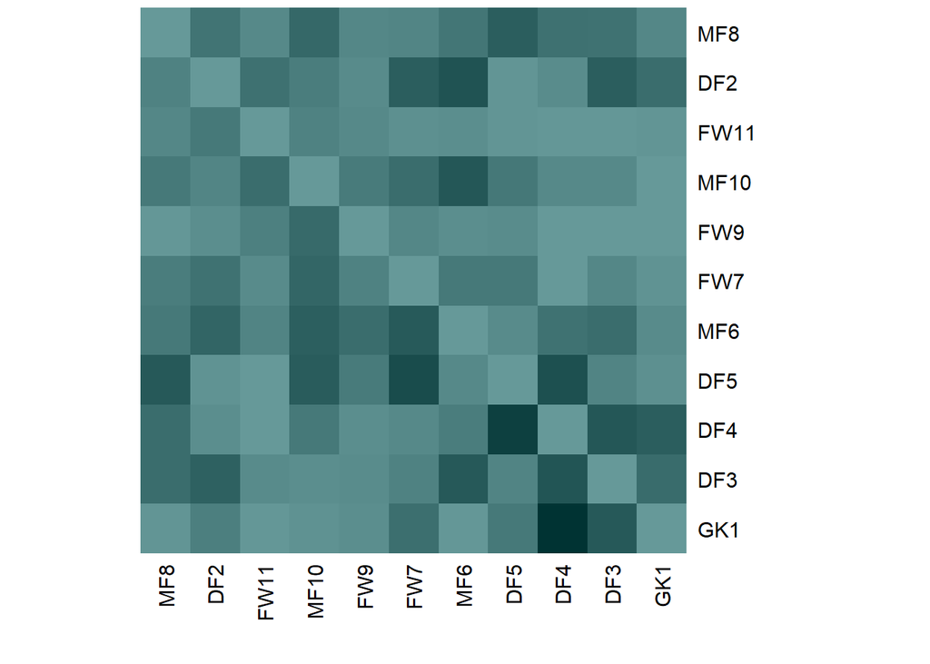

```r
palf <- colorRampPalette(c("#669999", "#003333"))
heatmap(FIFAm[,11:1],
        Rowv = NA,
        Colv = NA,
        col = palf(60),
        scale="none")
```

Tiparele descoperite anterior sunt vizibile si pe acest grafic.